# Building an Open Community around Software in Solar Physics

## Stuart Mumford

# How I Got Here!

### My PhD:

[video not shown]

### What I actually did:

#### A lot of SunPy

[figure not shown]

# Software in Science

### It's quite hard to avoid it!

- Scientists spend 30% of their time programming but 90% are self-taught. [1]
- It can be challenging to be rewarded for contributing to software.
- **Lots** of people writing the same code.
- Software is not often shared with publications.
- Communtiy software is rarely funded well. [2]

1. Wilson, G. et al. Best Practices for Scientific Computing. PLoS Biology 12, e1001745 (2014).  
2. Muna, D. et al. The Astropy Problem. ArXiv e-prints (2016).

# Open Community Driven Software

## Objectives:

- Build the core tools together.
- Save everyone time!
- Make the code citeable.
- Get subject matter experts and software developers working together.

## Questions:

- How to collaborate effiectively?
- How to keep the standard high when you have all levels of knowledge working on the code?
- How to encourage people to get involved?
- How to make it easy to use?

# Python in Astronomy

#### Python has seen a rapid adoption in Solar Physics and Astronomy

[figure not shown]

#### Python is now the most popular tool in astronomy.

[figure not shown]

1. Momcheva, I. & Tollerud, E. Software Use in Astronomy: an Informal Survey. ArXiv e-prints (2015).

# Why Python?

# Some Python Projects in Astronomy

[figure not shown]

- An open community of solar physicists, focused on Python.
- A project to manage the SunPy library and other related packages.
- A library of core tools for solar physicists in Python.

# SunPy Community

#### Mailing List

[figure not shown]

#### Real Time Chat

[figure not shown]

# SunPy Community

#### Twitter

[figure not shown]

#### GitHub

[figure not shown]

# Social Norms

## Code of Conduct

### A member of SunPy is:

#### Open

#### Considerate

#### Respectful

# Collaboratively Writing Code

## GitHub Workflow

[figure not shown]

## Submit Code

[figure not shown]

# Review Code

[figure not shown]

# Test Code

[figure not shown]

# Documentation

[figure not shown]

```
def rotate(self, angle=None):
        """
        Returns a new rotated and rescaled map.

        Parameters
        ----------
        angle : `~astropy.units.Quantity`
            The angle (degrees) to rotate counterclockwise.

        Returns
        -------
        out : `~sunpy.map.GenericMap` or subclass
            A new Map instance containing the rotated and rescaled data of the
            original map.

        See Also
        --------
        sunpy.image.transform.affine_transform : The routine this method calls
        for the rotation.

        Notes
        -----
        This function will remove old CROTA keywords from the header.
        This function will also convert a CDi_j matrix to a PCi_j matrix.

        See :func:`sunpy.image.transform.affine_transform` for details on the
        transformations, situations when the underlying data is modified prior
        to rotation, and differences from IDL's rot().
        """
```

[figure not shown]

# 66 Contributors to SunPy so far

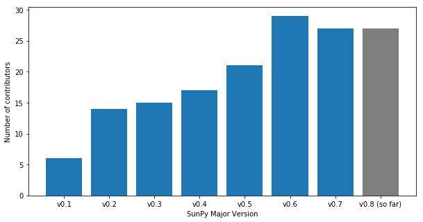

```python
labels, nums = np.array([[k, v] for k, v in authors_version.items()]).T

fig = plt.figure(figsize=(10, 5))
ax = plt.subplot()
ax.bar(np.arange(len(nums)), nums, color=['C0']*(len(nums)-1) + ['C7'])
ax.set_xticklabels(['']+list(labels))

ax.set_ylabel("Number of contributors")
ax.set_xlabel("SunPy Major Version")
ax.patch.set_alpha(0)

None
```

# Summer Students

[figure not shown]

# The SunPy Project

- Library Started in 2011.
- A board created to guide the project in 2015.
- Consists of multiple packages:
  - SunPy
  - SolarBExtrapolation
  - IRISPy
  - sunkit-sst
- Fiscally Sponsored by NumFOCUS

[figure not shown]

# The SunPy Library

- Nearly 8,000 changes (commits).
- 66 Contributors.
- 30 Releases.
- 500 resolved issues.
- 1,076 accepted code contributions (PRs).

[video not shown]

# SunPy!

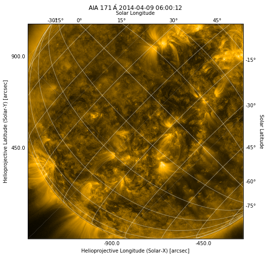

```python
from sunpy.data.sample import AIA_171_ROLL_IMAGE
import sunpy.map

aia = sunpy.map.Map(AIA_171_ROLL_IMAGE)

fig = plt.figure(figsize=(8,8))
ax = plt.subplot(projection=aia)

aia.plot()
aia.draw_grid()

a = ax.axis((500, 3000, 500, 3000))
```

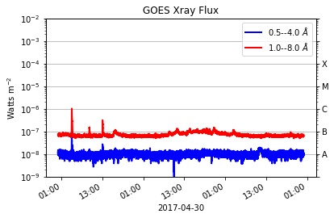

```python
import sunpy.timeseries
from sunpy.net import Fido, attrs as a

res = Fido.search(a.Time("2017/05/1", "2017/05/3"), a.Instrument("goes"))
files = Fido.fetch(res, progress=False)

ts = sunpy.timeseries.TimeSeries(files, concatenate=True)
fig = ts.peek()
```

# Interested?

- Join the mailing list.
- Try something out!
- Open an Issue.
- Hangout in the Chat.
- Correct the documentation.
- Write an example.
- Contribute a Feature.
- Get some grant money!